# Monte_Carlo_BS

## Monte Carlo Simulation : application to option pricing under Black-Scholes Model

### Monte Carlo Principle

The problem to solve here, is the computation of the quantity $\mathbb{E}(g(X))$, where $X$ is some random variable and $g$ some function with properties so that the expectation is well-defined.
Indeed, when one wants to compute the price of a call option, it needs to compute $\mathbb{E}^*\left[e^{-rT}(S_T - K)^+\right]$, under the risk-neutral probability measure $\mathbb{P}^*$: it is a particular case of the problem presented above.
So we need an estimator for the expectation. We can use the **Law of Large Numbers**:
Let $(X_i)_{1\leq i\leq N}$ be a sequence of **integrable, independently and identically distributed** random variables. We have the following convergence: $$ \bar{X} = \frac{1}{N}\sum_{i=1}^N X_i \xrightarrow[N\to +\infty]{} \mathbb{E}(X_1) $$ Obviously, we also have: $$ \frac{1}{N}\sum_{i=1}^N g(X_i) \xrightarrow[N\to +\infty]{} \mathbb{E}(g(X_1)) $$ So if we know how to simulate $(X_i)_{1\leq i\leq N}$, we know how to compute the expectation.

### I) Simulation of the underlying under Black-Scholes dynamic

```python
# Librairies
import numpy as np
import matplotlib.pyplot as plt
from scipy import stats
```

Black-Scholes diffusion is: $$ dS_t=\mu S_tdt + \sigma S_tdB_t $$ where $(B_t)_{t\geq0}$ is a Brownian motion under $\mathbb{P}$.

With Girsanov's Theorem, we can find $\mathbb{P}^* \sim \mathbb{P}$ such that, under this new measure, we have: $$ dS_t = rS_tdt + \sigma S_t dW_t $$ where $(W_t)_{t\geq0}$ is a Brownian motion under $\mathbb{P}^*$, and $r$ is the risk-free rate.

We can fin the solution under $\mathbb{P}^*$: $$ S_t = S_0e^{(r- \frac{\sigma^2}{2})t + \sigma W_t} $$ , where $W_t \sim \mathcal{N}(0,t)$.
We need to simulate a Gaussian real-valued random variable.

#### 1) Box-Müller formula

With $U_1$ and $U_2$ being independent and identically distributed. We have $U_1 \sim \mathcal{U}(0,1)$, the uniform law.
Then: $$ X_1 = \sqrt{-2log(U_1)}cos(2\pi U_2),\\ X_2 = \sqrt{-2log(U_1)}sin(2\pi U_2) $$ where $X_1, X_2$ are both distributed with $\mathcal{N}(0,1)$ and independent. With the central limit theorem: $$ \sqrt{t}X_1 \sim \mathcal{N(0,t)}\\ \sqrt{t}X_2 \sim \mathcal{N(0,t)} $$

```python
# Simulation with Box-Müller
# Given two vectors of uniformely distributed (0,1) values

def SimulateGaussians(U1, U2, variance=1):
    result = []
    if len(U1) != len(U2):
        raise Exception("We need same length for U1 and U2.")
    for i in range(len(U1)):
        result.append([np.sqrt(-2*variance*np.log(U1[i]))*np.cos(2*np.pi*U2[i]), np.sqrt(-2*variance*np.log(U1[i]))*np.sin(2*np.pi*U2[i])])

    return result
```

```python
# Testing

# -- Sample of 1000 realization of U(0,1)
U = np.random.uniform(0, 1, 1000)

# -- Box-Muller, variance = 1
gaussian_pairs = SimulateGaussians(U[:500], U[500:])
```

```python
# Kolmogorov-Smirnov test to check normality
# Null hypothesis : Generated values have the same distribrituion a X~N(0,1)
stats.kstest([gaussian_pairs[i][0] for i in range(int( len(U)/2 ))], "norm")
```

```
KstestResult(statistic=0.02408620460245159, pvalue=0.9269711619774674, statistic_location=1.062139392445644, statistic_sign=1)
```

If we take a threshold of $5\%$, we have a greater p-value, then we cannot reject null-hypothesis. The conclusion is that our generated sample is consistent.

### 2) Using numpy generator

```python
gaussians = np.random.normal(0, 1, 100) # Easiest way...
```

### 3) Now we simulate our paths

We can write with a discretization scheme : $$ S(t+\Delta t) = S_te^{(r-\frac{\sigma^2}{2})\Delta t + \sigma \sqrt{\Delta t}Z},\\ Z\sim \mathcal{N}(0,1) $$

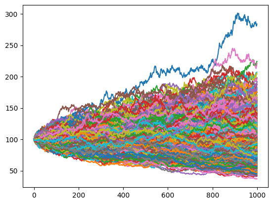

```python
_nbr_paths = 1000
_nbr_points = 1000
_spot = 100 # spot value of 100
_r = 0.
_vol = 0.2
_mat = 2 # year

_time_step = _mat/_nbr_points
S_t = np.zeros((_nbr_paths, _nbr_points));S_t[:, 0] = _spot

for i in range(_nbr_paths):
    gaussians = np.random.normal(0, 1, _nbr_points)
    for j in range(1, _nbr_points):
        S_t[i, j] = S_t[i, j-1]*np.exp((_r - .5*_vol**2)*_time_step + _vol*np.sqrt(_time_step)*gaussians[j])
    plt.plot(S_t[i])
plt.show()
```

### II) Price of a call option

We have the following payoff: $(S_T - K)^+$, so we want to compute $\mathbb{E}^*[e^{-rT}(S_T - K)^+]$.  
We write: $\psi(x)=e^{-rT}(x - K)^+$, the problem is then: $\mathbb{E}^*[\psi(S_T)]$.  
So we are going to apply this function to each path and compute the empirical estimator of $\mathbb{E}$.

```python
# We have the paths in S_t
_K = 120

def call_payoff(x, K, r, T):
    return np.exp(-r*T)*max(x - K, 0)

# Let's compute the call price on each path
call_paths = list(map(lambda x: call_payoff(x, _K, _r, _mat), S_t[:, _nbr_points-1]))
call_price = np.mean(call_paths)
```

```python
round(call_price, 2)
```

```
5.17
```

### II) Reduction of variance

Since the error of the Monte-Carlo is linked to the variance of the empirical estimator, we need to reduce that variance to get a more accurate result. We can also see that by building the confidence interval of the estimator, where the variance controls the size of the interval.

Indeed, if we write $\bar{X}_N = \frac{1}{N}\sum_{i=1}^NX_i$ (bias), then $\mathbb{E}(X) \in [\bar{X}_N -\alpha \frac{\sigma_N}{\sqrt{N}}, \bar{X}_N + \alpha \frac{\sigma_N}{\sqrt{N}}]$ where $\alpha$ is a quantile of $\mathcal{N}(0,1)$: if we take a $95\%$ confidence interval, then $\alpha = 1.96$. Hence to refine our estimate, we need to decrease $\sigma_N$ (since the rate of converge is $\frac{1}{\sqrt{N}}$, pretty slow, it is better to decrease $\sigma_N$).

#### 1) Control variates

We can write: $$ \begin{align} \mathbb{E}(g(X)) = \mathbb{E}(g(X)) - \mathbb{E}(h(X)) + \mathbb{E}(h(X)) \end{align} $$ where $\mathbb{E}(h(X))$ can be computed easily.
We know that the Put payoff, $(K - S_T)^+$ is bounded, then it is easier to compute its price.

By the Call-Put parity: $$ C_0 - P_0 = S_0 - Ke^{-rT} \implies C_0 = \mathbb{E}^*(e^{-rT}(K-S_T)^+) + S_0 - Ke^{-rT}. $$ It is in the form of equation $(1)$.

#### 2) Antithetic variables

If we have $X$ a real-values random variable, and $\Gamma$ a transformation of $\mathbb{R}$ such that the law of $\Gamma(X)$ is the same as the law of $X$, we can write: $$ \mathbb{E}(g(X)) = \frac{1}{2}\Bigl[g(X) + g(\Gamma(X))\Bigr] $$

For the standard Monte-Carlo ($(X_i)_{i\in I}$ are identically distributed and independent): $$ \frac{1}{2n}\sum_{i=1}^{2n}g(X_i) = \frac{1}{n}\sum_{i=1}^{2n}\frac{1}{2}g(X_i) = I_{2n}. $$ Then: $$ Var(I_{2n}) = \frac{1}{2n}Var(g(X_1)) $$

If we compute the variance of the new estimator: $$ \begin{align} Var\Bigl[\frac{1}{n} \sum_{i=1}^{2n} \frac{1}{2} \bigl(g(X_i) + g(\Gamma(X_i))\bigr)\Bigr] & =\frac{1}{4n}\Bigl[Var(g(X_1)) + Var\bigl(g(\Gamma(X_1))\bigr) + 2Cov\Bigl(g(X_1), g(\Gamma(X_1))\Bigr)\Bigr]\\ & = \frac{1}{2n}\Bigl( Var\bigl(g(X_1)\bigr) + Cov\Bigl(g(X_1), g(\Gamma(X_1))\Bigr) \Bigr) \end{align} $$

We can deduce that if $Cov\Bigl(g(X_1), g(\Gamma(X_1))\Bigr) < 0$, the variance of the estimator is descreased with this formula.  
For our pricing, $\forall \space 0 < t \leq T, W_t \sim \mathcal{N}(0,t)$.  
We can take $\Gamma(W_t) = -W_t$, as $W_t$ and $-W_t$ have the same law, and $Cov\Bigl(W_t, -W_t\Bigr) = -t < 0$.

```python
S_t_antithetic = np.zeros((_nbr_paths, _nbr_points));S_t_antithetic[:, 0] = _spot

for i in range(_nbr_paths):
    gaussians = -1*np.random.normal(0, 1, _nbr_points)
    for j in range(1, _nbr_points):
        S_t_antithetic[i, j] = S_t_antithetic[i, j-1]*np.exp((_r - .5*_vol**2)*_time_step + _vol*np.sqrt(_time_step)*gaussians[j])

for i in range(_nbr_paths):
    gaussians = np.random.normal(0, 1, _nbr_points)
    for j in range(1, _nbr_points):
        S_t[i, j] = S_t[i, j-1]*np.exp((_r - .5*_vol**2)*_time_step + _vol*np.sqrt(_time_step)*gaussians[j])
```

```python
# We have the paths in S_t
_K = 120

def call_payoff(x, K, r, T):
    return np.exp(-r*T)*max(x - K, 0)

def antithetic_mean(prices, prices_antithetic):
    return (1/(2*len(prices)))*(sum(prices) + sum(prices_antithetic))

# Let's compute the call price on each path
call_paths_antithetic = list(map(lambda x: call_payoff(x, _K, _r, _mat), S_t_antithetic[:, _nbr_points-1]))
call_paths = list(map(lambda x: call_payoff(x, _K, _r, _mat), S_t[:, _nbr_points-1]))
call_price = antithetic_mean(call_paths, call_paths_antithetic)
```

```python
round(call_price, 2)
```

```
4.85
```